# Time series analysis

Villaseñor-Derbez, J.C.

11 de febrero de 2016

# Part 1, Intro to TS

## First we load the packages that will be used:

```r
suppressPackageStartupMessages({
  library(forecast)
  library(tidyverse)
})
```

## Read the csv data and plot the Temperature agains month elasped

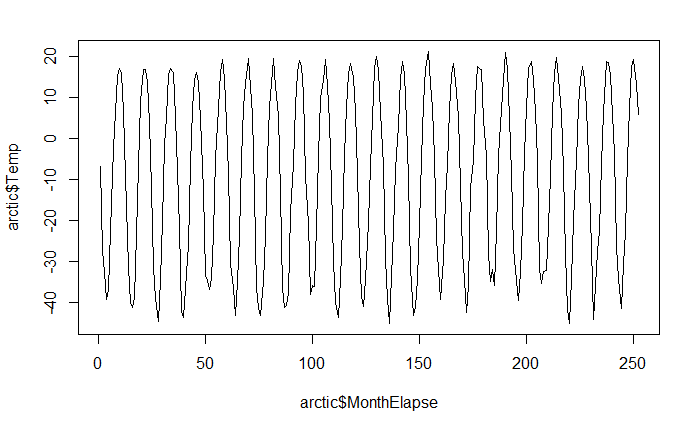

```r
arctic <- read.csv("ArcticTemp.csv")
plot(arctic$MonthElapse, arctic$Temp, type="l")
```

## convert to `ts` object

- Create a variable called `TempData` with just the temperature data
- Use `ts` to convert the data, specify the frequency of the cycle (12 for 12 months) and the year and month of first smapling
- `ts` objects can be directly plotted with base `plot`

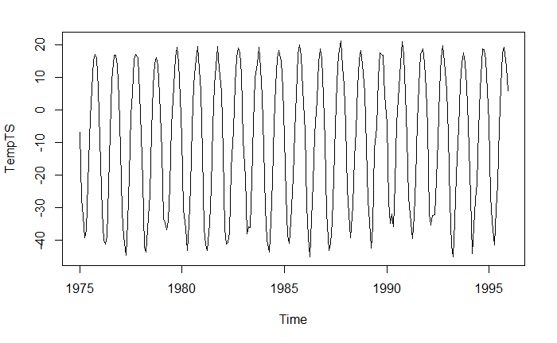

```r
TempData <- arctic$Temp
TempTS <- ts(data=TempData, frequency=12, start=c(1975,1))
plot(TempTS)
```

## Decompose a time series

- A time series might have different components to it (seasonal, annual, decadal…), and we want to extract all that info
- Use `decompose` and base `plot` to look at the temporal trend, seasonal signature, and random noise in the data

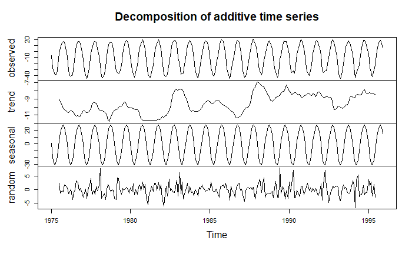

```r
DecompTemp <- decompose(TempTS)
plot(DecompTemp)
```

## Forecasting

### Calculate parameters for existing data

- Use `HoltWinters` to “fit” the data
- Use base `plot` to see observed (black) and fitted (red) values

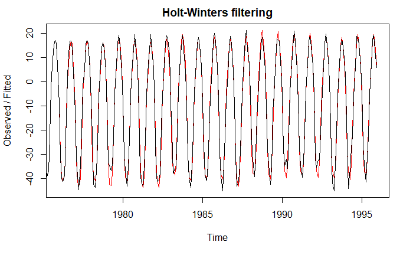

```r
Forecast <- HoltWinters(TempTS)
plot(Forecast)
```

### Forecast into the future

- Use what `HoltWinters` calculated to feed `forecast`
- `forecast` needs ou to specify how many points you want. In this case, we want 4 years so 4 Y * 12 M = 48 points.
- Use base `plot` to look at the projection

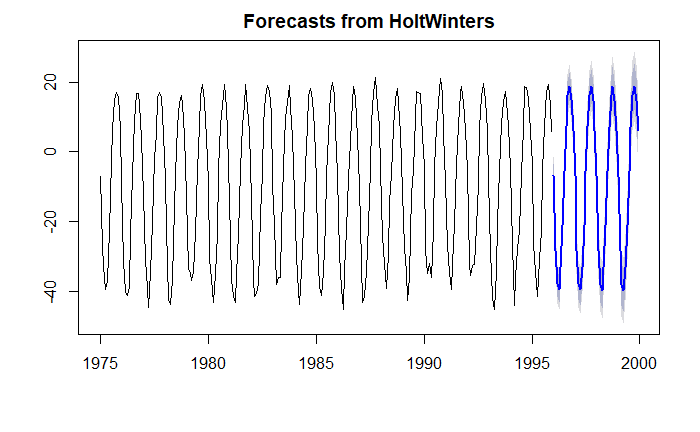

```r
Forecast2 <- forecast(Forecast, h=48)
plot(Forecast2)
```